# Финансовые риски

А.Н.Дойников

February 8, 2022

```r
library(PerformanceAnalytics)
```

# Виды рисков

Во всем многообразии финансовых рисков обычно выделяют:

- Кредитный риск (Credit Risk) - риск возможных потерь из-за неспособности контрагента выполнить свои обязательства называемое дефолтом.
- Операционный риск (Operational Risk) - риск потерь из-за ошибок операционного персонала.
- Риск несбалансированной ликвидности (Liquidity Risk) - потери, которые могут возникнуть в ситуации, когда для обеспечения ликвидности приходится привлекать дополнительные средства под более высокий процент, чем обычно.
- Рыночный риск (Market Risks) - риск, связанный с возможным изменением рыночных котировок активов и изменением процентных ставок.

Конечно, деление это условно, а виды рисков взаимосвязаны. Но эта классификация представляется разумной, поскольку для оценки и управления разными рисками применяются разные методы. Так управление операционными рисками и риском ликвидности в значительной степени носит характер проблемы, решаемой построением правильной организационной процедуры с опорой на знания экспертов.

Управление рыночными рисками, в его современном понимании, наиболее формализуемая и регулярная задача. Первые математические модели изменения рыночных цен появились еще в начале ХХ века. В данной лекции мы остановимся на методах оценки рыночного риска.

# Логарифмические доходности

Сначала подготовим данные

```r
asset <- read.csv("GAZPROM.csv")
asset[,1] <- as.Date(asset[,1],"%d/%m/%y")
len<-  dim(asset)[1]
b <- 20
head(asset)
```

```
##      X.DATE. GAZPROM    MOEX
## 1 2017-04-03  127.21 2008.61
## 2 2017-04-04  128.81 2025.69
## 3 2017-04-05  130.69 2056.32
## 4 2017-04-06  130.50 2054.69
## 5 2017-04-07  128.72 2020.23
## 6 2017-04-10  126.16 1971.23
```

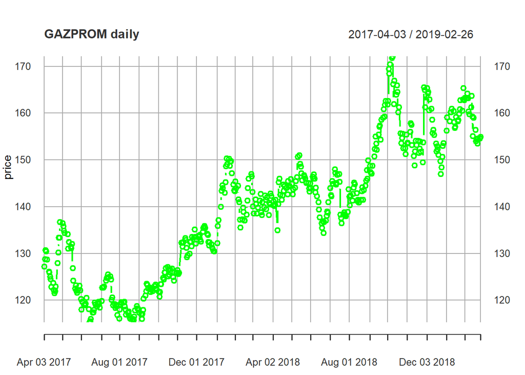

```r
asset.xts <- as.xts(cbind(asset[,2],asset[,3]), order.by = asset[,1])
colnames(asset.xts)<- c("GAZPROM","MOEX")
plot(asset.xts[,'GAZPROM'],type = 'b',main="GAZPROM daily",pch = 21, col = "green",lwd = 2,xlab= 'data',ylab = "price" )
```

Переходим к логарифмическим доходностям

```r
len<-  dim(asset)[1]
r1 <- diff(log(asset[,2]))
r2 <- diff(log(asset[,3]))
rates.xts <- as.xts(  cbind(r1,r2), order.by = asset[2:len,1])
colnames(rates.xts)<- c("GAZPROM","MOEX")
head(rates.xts)
```

```
##                 GAZPROM          MOEX
## 2017-04-04  0.012499186  0.0084674427
## 2017-04-05  0.014489656  0.0150075942
## 2017-04-06 -0.001454880 -0.0007929925
## 2017-04-07 -0.013733724 -0.0169136187
## 2017-04-10 -0.020088560 -0.0245536529
## 2017-04-11 -0.001269036  0.0034032414
```

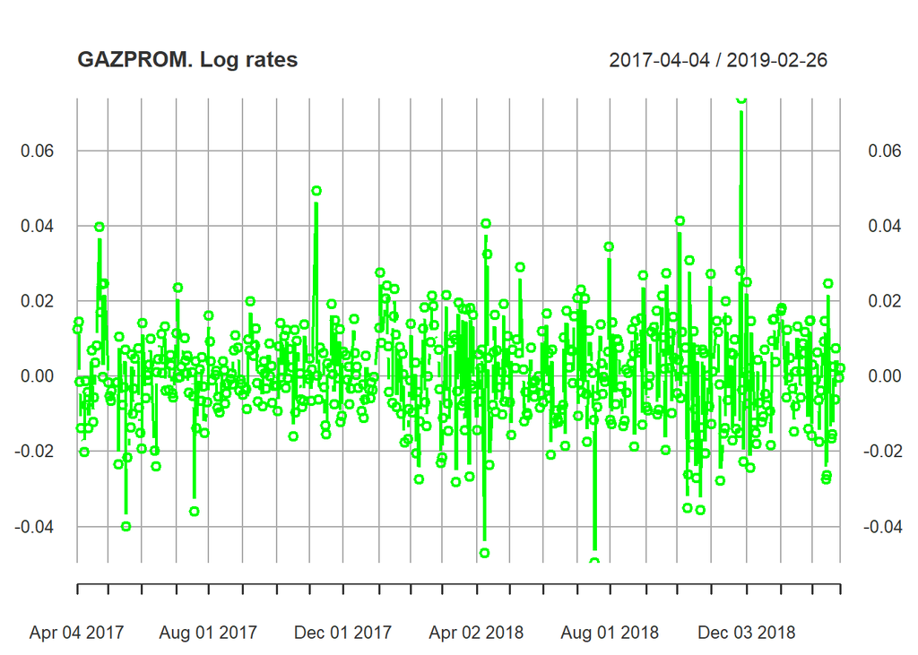

```r
plot(rates.xts[,'GAZPROM'],main= 'GAZPROM. Log rates',type ='b',pch =21,col = 'green')
```

# Коэффициенты бета и альфа

Одним из популярных методов оценки рыночного риска является расчет и анализ систематического рыночного риска - бета коэффициента, оценивающего чуствительность риска акции к риску всего рынка в целом. Согласно модели ОЦЕНКИ КАПИТАЛЬНЫХ АКТИВОВ (Capital Asset Pricing Model или CAMP) - разработанной Джеком Трейнором (1961, 1962), Уильямом Шарпом (1964), Джоном Литнером (1965) и Яном Моссином (1966) в 60-х годах прошлого века независимо друг от друга. Согласно этой теории коэффициент бета вычисляется по формуле

$$\beta_{i}=\frac{cov(\rho_{i},\rho)}{D[\rho]}$$
где

- $\rho_i$ - доходности i -го актива;
- $\rho$ - доходности всего рынка в целом, вычисленнную по биржевому индексу.

Вычислим эту характеристику рыночного риска непосредственно по определению и через метод `CAPM.beta()` из библиотеки *PerformanceAnalytics*

```r
beta_manual <- cov(rates.xts[, "GAZPROM"],rates.xts[, "MOEX"])/ var(rates.xts[, "MOEX"])
beta_manual
```

```
##             MOEX
## GAZPROM 1.047184
```

```r
beta <- CAPM.beta(rates.xts[, "GAZPROM"],rates.xts[, "MOEX"])
beta
```

```
## [1] 1.047184
```

Теория оценки акций предполагает, что премия за риск растёт пропорционально $\beta$-коэффициенту акции или инвестиционного портфеля.

Модель оценки долгосрочных активов имеет следующий вид:
$$E(R_{i})=R_{f}+\beta _{{i}}(E(R_{m})-R_{f})$$

где:

$E(R_{i})$ — ожидаемая ставка доходности на долгосрочный актив;

$R_{f}$ — безрисковая ставка доходности;

$\beta _{i}$ — коэффициент чувствительности актива к изменениям рыночной доходности

$E(R_{m})$ — ожидаемая доходность рыночного портфеля;

В реальности конечно равенства мы здесь не увидим, но разность между частями последнего соотношения получила название альфа коэффициента, и характеризует несистематический (специфический риск активов)
$$\alpha_i=E(R_{i})-R_{f}-\beta _{{i}}(E(R_{m})-R_{f})$$

Вычислим коэффициент $\alpha_i$ непосредственно по формуле и сравним с результатом `CAPM.alpha()` из библиотеки *PerformanceAnalytics*.

```r
Rf <- 0.07
(alpha_manual <- mean(rates.xts[, "GAZPROM"])-Rf- beta*(mean(rates.xts[, "MOEX"])- Rf))
```

```
## [1] 0.003241773
```

```r
(alpha <- CAPM.alpha(rates.xts[, "GAZPROM"],rates.xts[, "MOEX"],Rf = 0.07))
```

```
## [1] 0.003241773
```

# Коэффициент Шарпа

Коэффициент Шарпа был разработан нобелевским лауреатом Вильямом Шарпом в 1966 году и используется для измерения уровня риска в инвестиционном портфеле .

Следовательно, чем выше коэффициент Шарпа, тем лучше результаты, которые показывает инвестиционный портфель по отношению к принятым рискам.

Коэффициент Шарпа для портфеля вычисляется по формуле

$$S=\frac{E[r_{p}-r_f]}{\sqrt{D[r_{p}-r_f]}}$$

где

$r_{p}$-доходность портфеля за некоторый промежуток времени

$r_f$ - безрисковая доходность за такой же период времени

При сравнении двух портфелей с одинаковой доходностью предпочтительнее является портфель с большим коэффициентом Шарпа, а следовательно с меньшем риском $D[r_{p}-r_f]$.

Сравним портфели, состоящие из 1-ой акции ГАЗПРОМ и 1-го индекса Московской биржи. Как обычно вычислим непосредственно по определению и возпользуемся соответсвующим методом из библиотеки *PerformanceAnalytics*.

```r
mean(rates.xts[, "GAZPROM"]-Rf)/sd(rates.xts[, "GAZPROM"]-Rf)
```

```
## [1] -5.155025
```

```r
mean(rates.xts[, "MOEX"]-Rf)/sd(rates.xts[, "MOEX"]-Rf)
```

```
## [1] -7.287045
```

```r
SharpeRatio(rates.xts[, "GAZPROM"], Rf = Rf, p = 0.95, FUN = c("StdDev"))
```

```
##                                 GAZPROM
## StdDev Sharpe (Rf=7%, p=95%): -5.155025
```

```r
SharpeRatio(rates.xts[, "MOEX"], Rf = Rf, p = 0.95, FUN = c("StdDev"))
```

```
##                                    MOEX
## StdDev Sharpe (Rf=7%, p=95%): -7.287045
```

# Показатель Value at Risk (VAR)

**Определение** Value at Risk - выраженная в денежных единицах оценка величины, которую не превысят ожидаемые в течении заданного периода времени потери с заданной вероятностью.

Вот как ее можно определить. Обозначим через X потери нашего портфеля через $N$ дней. Потери эти являются величиной случайной и зависят от изменения котировок финансовых инструментов, входящих в портфель, за период N дней. Величина
$$q=VAR_{\alpha}(X)$$

есть квантиль уровня $\alpha$ распределения случайной величины $X$, т.е. вероятноять того, что $X$ не превосходит $q$, равна $\alpha$ . Вычислив VAR, мы можем формулировать утверждения типа : “Мы на $\alpha*100%$ уверены, что не потеряем более, чем q за ближайшие N дней”.

Методологии вычисления VAR посвящено громадное количество литературы. Он используется не только трейдерами и портфельными менеджерами, но и регулирующими органами. Так в США регулирующие органы требуют от банков резервировать трехкратный 10-дневный 99% VAR под рыночные риски.

Несмотря на свою популярность, VAR обладает рядом существенных недостатков:

- VAR не учитывает возможных больших потерь, которые могут произойти с маленькими вероятноcтями (меньшими, чем $\alpha$;
- VAR не может различить разные типы хвостов распределения потерь и поэтому недооценивает риск в случае, когда распределение потерь имеет “тяжелые хвосты” (т.е. его плотность медленно убывает).
- VAR не является когерентной мерой, в частности, он не обладает свойством субаддитивности. Можно привести примеры, когда VAR портфеля больше, чем сумма VAR двух подпортфелей, из которых он состоит. Это противоречит здравому смыслу. Действительно, если рассматривать меру риска как размер капитала, резервируемого для покрытия рыночного риска, то для покрытия риска всего портфеля нет необходимости резервировать больше, чем сумму резервов составляющих подпортфелей.
- VAR поощряет торговые стратегии, которые дают хороший доход при большинстве сценариев, но иногда могут приводить к катастрофическим потерям.

# Методы оценки Value at RISK

## Дельта- Нормальный VAR

Главная предпосылка здесь заключается в нормальном распределении изменений фактора первичных активов. В частности, в модели арифметического броуновского движения предполагается нормальная распреденность изменения цен акции за заданный промежуток времени

$$S_{t}-S_{t-1}\sim N(\mu,\sigma^2)$$
а в модели геометрического броуновского движения логарифма отношения цен- логарифмическая доходность

$$ln(((S_{t})/(S_{t-1})))=lnS_{t}-lnS_{t-1}∼N(\mu,\sigma^2)$$

В частности, в арифметической модели если дневная волатильность одной акции равна $\sigma$, а $\mu=0$, то 99% однодневный VAR портфеля из $b$ акций равняется
$$VAR_{0.99}=2.33b \sigma$$
где 2.33 как раз квантиль нормального распределения уровня 0.99.

```r
(qnorm(0.99,mean=0,sd=1))
```

```
## [1] 2.326348
```

Для примера пусть у нас $b=20$ акций ГАЗПРОМ . Считаем цены акций ГАЗПРОМ и индекс Московской биржи приблизительно за 2 года.

## Нормальная модель VAR (Арифметическая модель)

Здесь также предполагаем нормальное распределение приращения стоимости актива за день Вычисляем прирашения стоимости одной акции и оцениваем среднее за день и дневную волатильность (стандартное отклонение)

```r
 dif <- diff(asset[,2])
 mean_dif <- mean(dif)

 vol <- sd(dif)
```

Вычисляем однодневный VAR уровня $\alpha=0.95 * 100$%

```r
  alpha = 0.95
  (VAR1 = qnorm(1-alpha,mean=mean_dif,sd=1)*vol)
```

```
## [1] -3.099745
```

```r
  (VAR10 = qnorm(1-alpha,mean=mean_dif,sd=1))
```

```
## [1] -1.587182
```

```r
  (VARb = VAR1*b)
```

```
## [1] -61.99489
```

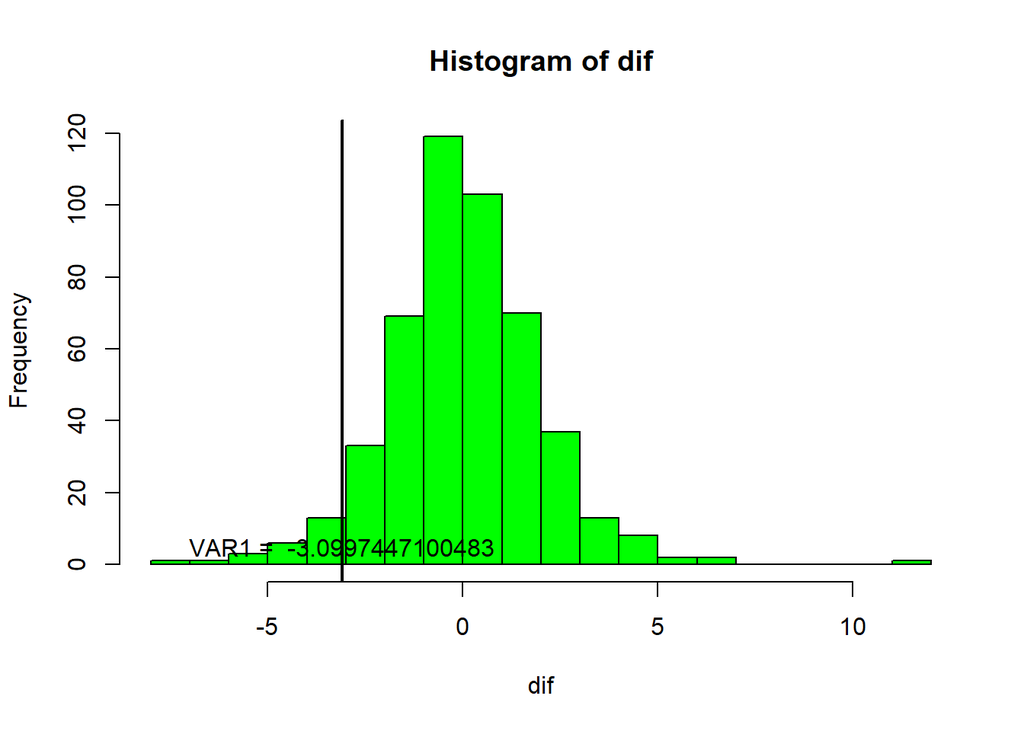

```r
  hist(dif,col = "green",nclass = 20)
  abline(v = VAR1,lwd = 2)
  text(VAR1,5,paste("VAR1 = ",VAR1))
```

## Нормальная модель VAR (Геометрическая модель)

В геометрической модели предполагается, что логарифм отношения цен- или логарифмическая доходность. Т.е. сам актив имеет логнормальное распределение.

$$ln(((S_{t})/(S_{t-1})))=lnS_{t}-lnS_{t-1}∼N(\mu,\sigma^2)$$
имеет нормальное распределение Пусть

- S — стоимость единицы актива
- $\mu$ — математическое ожидание доходности позиции за единицу времени,
- $\sigma$ — волатильность позиции в единицу времени,
- $T$ — оцениваемый горизонт.

Соответственно, для логнормального распределения справедливо следующее соотношение

$$VaR=S(1-e^{-\mu _{i}T+z_{\alpha }\sigma _{i}{\sqrt {T}}})$$
где $z_{\alpha}$- односторонняя $\alpha$ -квантиль стандартного нормального распределения.

## Исторический VAR

### Арифметическая модель

Пусть портфель состоит из N активов. Для каждого i-го актива $i=1,...,N$ вычисляются приращения
$$ΔS_{t}^{i}=S_{t}^{i}-S_{t-1}^{i}$$
Далее вычисляются изменение всего портфеля из $b = (b_1,...,b_N)$ активов.
$$Δ\Pi_t= \Sigma_{i=1}^N b_i ΔS_{t}^{i}$$
Ряд $Δ\Pi_1,...,Δ\Pi_T$ упорядочивается по возрастанию. Вычисяется индекс $k = [T*(1-0.95)]$ элемента упорядоченного ряда,значение $-Δ\Pi_{(k)}$ и полагается как значение VAR заданного уровня.
Либо другими словами исторический VAR это соответствующий квантиль заданного уровня, полученный по эмпирической функции распределения изменений портфеля, умноженной на -1. Главное достоинство здесь быстрота и простоа, а недостаток - неточность при слишком малом числе исторических наблюдений.

```r
 # first do normal VaR calc
library(PerformanceAnalytics)
  data_dif <- as.xts(dif,asset[2:length(asset[,1]),1])
  head(data_dif)
```

```
##             [,1]
## 2017-04-04  1.60
## 2017-04-05  1.88
## 2017-04-06 -0.19
## 2017-04-07 -1.78
## 2017-04-10 -2.56
## 2017-04-11 -0.16
```

```r
  (VaR(data_dif, p=.95, method="historical"))
```

```
## VaR calculation produces unreliable result (risk over 100%) for column: 1 : 2.94
```

```
##     [,1]
## VaR   -1
```

Вычислим по определению как квантиль эмпирической функции распределения уровня $\alpha=0.05,0.95$

```r
  (-1*quantile(data_dif,c(.05,.95)))
```

```
##    5%   95%
##  2.94 -3.02
```

## Исследование распределения потерь

Построим нормальный q-q plot для приращений акций ГАЗПРОМА

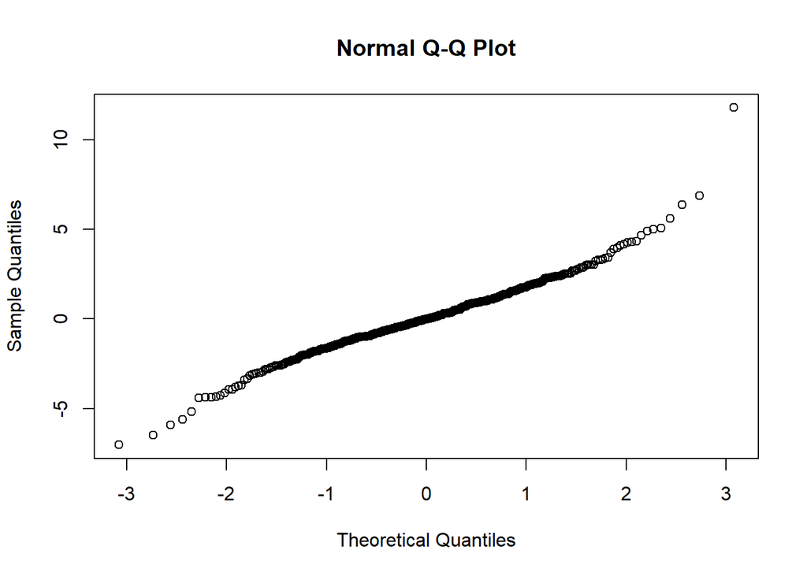

```r
d1 <- diff(asset[,2])
qqnorm(d1)
```

Загнутость на концах графика говорит о распределениях с тяжелыми хвостами. Попробуем оценить Value at Risk по распределению с тяжелыми хвостами, а именно по распределению Стьдента.

### VAR по распределению Стьюдента

Оценим параметры распределения и вычислим VAR для одной акции.

```r
library(MASS)
dd1 <- (d1-mean(d1))/sd(d1)
vol <- sd(d1)
(t_param <- fitting_normal<-fitdistr(d1,"t"))
```

```
##        m            s            df
##   0.03088392   1.53974485   5.30883098
##  (0.08066530) (0.08398513) (1.24087003)
```

```r
(t_param <- fitting_normal<-fitdistr(dd1,"t"))
```

```
##         m             s            df
##   -0.01371110    0.78840606    5.30889635
##  ( 0.04130357) ( 0.04300354) ( 1.24090954)
```

```r
df <- t_param$estimate[3]
alpha <- 0.95
(VAR20 <- qt(1-alpha,df))
```

```
## [1] -1.989436
```

```r
(VAR2 <- qt(1-alpha,df)*vol)
```

```
## [1] -3.885341
```

## Другие распределения , используемые для оценки VaR

Основной задачей исследователя это подбор наиболее адекватного распределения, которое будет использовано при оценки VaR. К таким распределениям кроме Нормального и Стьюдента относятся:распределения Лапласа, Variance Gamma,Парето. В последнее время популярным стало распределение Variance Gamma, так как оно позволяет учитывать некоторые особенности финансовых рынков, это тяжелые хвосты и асимметричность Свойства этого распределения демонстрирует следующий фрейм https://shiny.ilykei.com/ANDoynikov/Distributions/variance_gamma_distribution/

В R распределение Variance Gamma не входит в список стандартных и чаще всего используемых распределений, однако есть библиотека для работы конкретно с этим распределением это `library(VarianceGamma)`. Для заитересовавшихся этим распрелелением советую для первого знакомства посмотреть википедию

https://wikichi.ru/wiki/Variance-gamma_distribution

## VAR для многокомпонентного портфеля

Пусть имеется $N$ активов, стоимость которых $S_t(i),i = 1,...,N$ может случайным образом изменяться. Темпы возможного прироста стоимости активов обозначим $r_t=(r_t(1),....,r_t(N))$ и назовем их доходностями.

Обозначим через $\Sigma =[\sigma _{ij}]$ — ковариационную матрицу доходностей. Все доходности вычисляются для выбранного периода.

Портфель активов характеризуется вектором структуры $d=(d_{1},d_{2},...,d_{n})$, где
$$d_{i}=S_{i}/ \sum _{j=1}^N S_{j}$$
— доля стоимости i-го актива в портфеле.

Тогда доходность портфеля выразится через доходности активов следующим образом:
$$r_{p}=d^{T}r= \sum _{i=1}^{n}d_{i}r_{i}$$

Тогда ожидаемая (математическое ожидание) доходность портфеля выражается через ожидаемые доходности активов следующим образом:

$$\mu _{p}=E(r_{p})=d^{T}E(r)= \sum _{i=1}^{n}d_{i}E(r_{i})$$

а дисперсия портфеля будет равна

$$\sigma _{p}^{2} = d^{T}\Sigma d=\sum _{i=1}^{n}\sum _{j=1}^{n} \sigma _{ij}d_{i}d_{j}\sigma _{p}^{2}$$
Если предполагается нормальное распределение доходностей, то для заданной вероятности $\alpha$ (например, 5 % или 1 %):

$$P(r_{p}<\mu _{p}-z_{\alpha }\sigma _{p})=\alpha$$
где $z_{\alpha }$ — односторонняя $\alpha$ -квантиль стандартного нормального распределения.

Остается от VAR для доходностей перейти к VAR для цен активов портфеля.

Пусть стоимость портфеля $S_p=\sum_{i=1}^nS_i$ и предположим, что она получена в последний момент времени наблюдений. Тогда величина VaR оценивается как

$$VaR=S_{p}(-\mu _{p}T+z_{\alpha }\sigma _{p}{\sqrt {T}})$$
здесь $T$ - оцениваемый горизонт.

## Когерентные меры риска

Понятие когерентных мер риска было введено сравнительно недавно. Обозначим через X случайную величину, выражающую размер возможных потерь к некоторому моменту T в будущем. Когерентной в указанной работе была названа мера риска r , обладающая следующими четырьмя свойствами :

- $r(X) = r(max(X,0))$;
- $r(X + Y) <= r (X) + r(Y)$;
- для всякого положительного числа $\lambda$ $r(X) = r(\lambda X)$;
- для всякого положительного X и числа $A > 0$ $r(A+ X) = A + r(X)$ Эти условия являются естественными требованиями, которые следует предъявлять к мере риска.

Многих недостатков свойственных VARу лишен Shortfall. Обозначим, как и при определении VAR, через X потери нашего портфеля через N дней, $q = VAR_{\alpha}(X)$, тогда Shortfalla(X) есть условное математическое ожидание X при условии, что X больше q
$$Shortfall_{\alpha} (X) = E(X|X>q)$$
Shortfall является более консервативной мерой риска, чем VAR. Для одного и того же уровня $\alpha$ он требует резервировать больший капитал.

Для непрерывных распределений c плотностью распределений f(x) потерь и доходов

$$Shortfall_{\alpha}(X)= \frac{∫_{-∞}^{Var_{\alpha}}xf(x)dx}{∫_{-∞}^{Var_{\alpha}}f(x)dx}=\frac{∫_{-∞}^{Var_{\alpha}}xf(x)dx}{\alpha}$$
Оценим $Shortfall_{\alpha}$ для доходностей ГАЗПРОМА и индекса Московской биржи при предположении нормальности распределения доходностей

```r
ES(rates.xts, p=.95, method="gaussian")
```

```
##        GAZPROM        MOEX
## ES -0.02740637 -0.01921674
```

Оценим исторический $Shortfall_{\alpha}$ для доходностей ГАЗПРОМА и индекса Московской биржи.

```r
ES(rates.xts, p=.95, method="historical")
```

```
##        GAZPROM        MOEX
## ES -0.02819654 -0.01998467
```

## Чувствительность мер риска к изменению его уровня

Бывает часто очень полезно посмотреть чувствительность мер риска к изменению уровня $\alpha$.

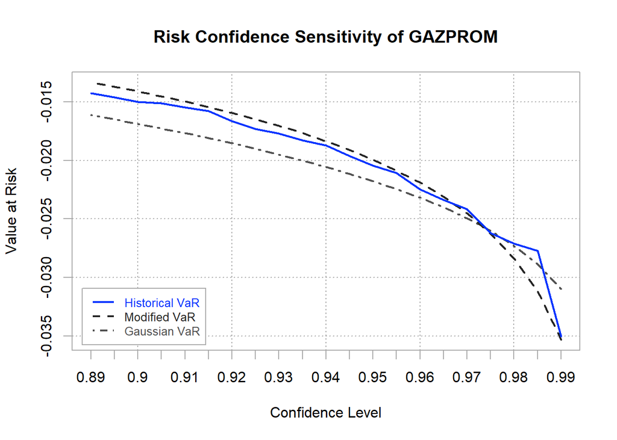

```r
chart.VaRSensitivity(rates.xts[,"GAZPROM"],
                     methods=c("HistoricalVaR", "ModifiedVaR", "GaussianVaR"),
                     colorset=bluefocus, lwd=2)
```

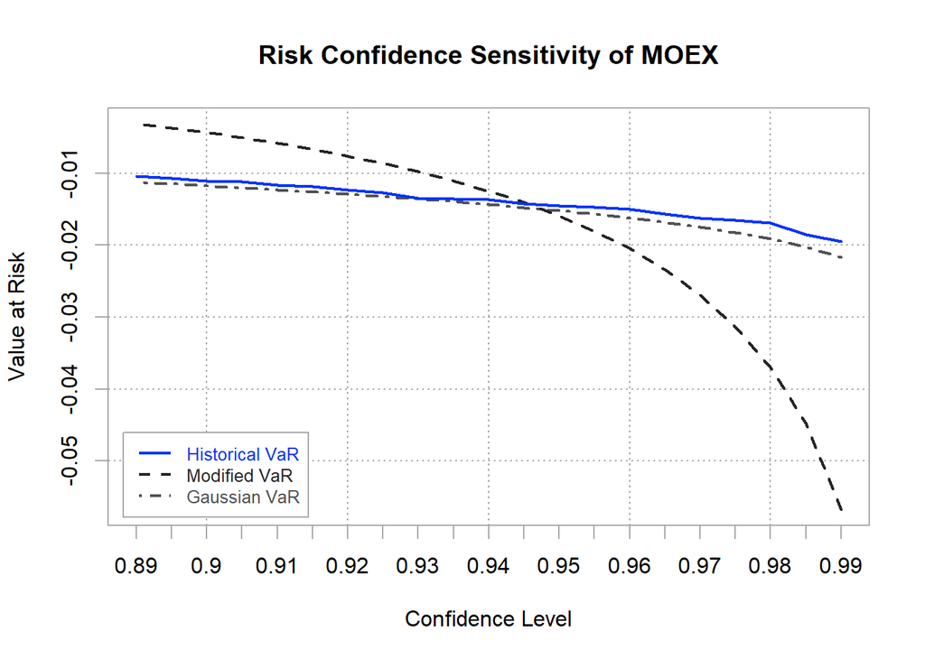

```r
chart.VaRSensitivity(rates.xts[,"MOEX"],
                     methods=c("HistoricalVaR", "ModifiedVaR", "GaussianVaR"),
                     colorset=bluefocus, lwd=2)
```